# 数据操作

# 1 数据操作描述

数据操作涉及：数据介绍与说明、数据字符函数、数据读取、数据合并、数据分割、数据的抽样、数据筛选、数据清洗、数据缺失值处理、数据输出等。

# 2 数据介绍与说明

## 2.1 **数据是什么？**

1)部分学者认为：数据是科学实验、检验、统计等所获得的和用于科学研究、技术设计、查证、决策等的数值。

2)部分专家认为：一切可以记录的信息，包括声音、图像、文字、数字、事件等等都叫做数据。

3)部分网页展示：数据是信息的表现形式和载体，可以是符号、文字、数字、语音、图像、视频等。

4)数据和信息是不可分离的，数据是信息的表达，信息是数据的内涵。数据本身没有意义。 数据只有对实体行为产生影响时才成为信息。

## 2.2 **以excel数据为例说明**

以最为常见的Excel数据为例，对其说明如下：

1个横向的行数，称为数据的一条记录。该条记录，能够反馈出数据中的一部分完整信息。

1个纵向的列数，称为数据的一个属性，有时也叫个案，或者叫一个字段。能够反馈数据一个特征下的所有信息。

| 序号 | 原价 | 促销价 | 销量 | 评价 | 保修期 | 店铺分类 | 使用位置 | 功效 |
| --- | --- | --- | --- | --- | --- | --- | --- | --- |
| 1 | 1664 | 499 | 845 | 2849 | 1年 | 官方旗舰店 | 终端净水 | 直饮 |
| 2 | 6990 | 1298 | 550 | 3049 | 1年 | 官方旗舰店 | 终端净水 | 直饮 |
| 3 | 4998 | 1099 | 121 | 129 | 1年 | 官方旗舰店 | 终端净水 | 直饮 |
| 4 | 4999 | 558 | 86 | 378 | 2年 | 官方旗舰店 | 终端净水 | 直饮 |
| 5 | 2099 | 1188 | 567 | 2054 | 5年 | 官方旗舰店 | 中央净水 | 非直饮 |
| 6 | 2119 | 1198 | 1050 | 1639 | 1年 | 专营店 | 终端净水 | 直饮 |
| 7 | 3999 | 998 | 5 | 10 | 2年 | 官方旗舰店 | 终端净水 | 直饮 |
| 8 | 2499 | 1628 | 1201 | 1404 | 5年 | 官方旗舰店 | 中央净水 | 非直饮 |

由以上数据的展示记录再结合下面的数据变量说明，可知第7条数据中的净水器商品原价是3999元，促销价为998元，销量是5台，评价是10次，保修期是2年，店铺类型为官方旗舰店，使用位置是终端净水，功效属于直饮净水器。

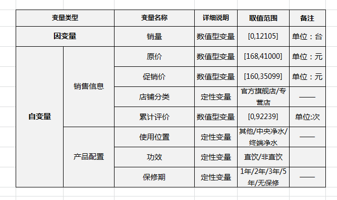